# Coursework 1 - Mathematical Methods for Bioengineers

**Author**: Jorge Bennasar Vázquez | **CID**: 01809233

```python
import numpy as np
import matplotlib.pyplot as plt
from mpl_toolkits.mplot3d import Axes3D
from sklearn.metrics.pairwise import cosine_similarity
import scipy.io as sio
from scipy.signal import correlate,periodogram,welch,butter,sosfilt
from scipy.spatial.distance import pdist, squareform
from sklearn.manifold import MDS
from scipy.fftpack import fft
import scipy.stats as stats
```

## Section 1

The uploaded data corresponds to the fluorescence time series obtained by imaging two pyramidal neurons in the hippocampal region CA1 while a mouse is running around a circular track, the corresponding x and y coordinates of the trajectory, the angular position of the mouse and the frequency of recording (fs). In section 1 three plots are displayed. The first of them corresponds to the fluorescence time series of the two neurons (4 and 7), where a high fluorescence shows neuronal action potentials. The second plot shows the angular position (in degrees) of the mouse as a function of time. Lastly, the third plot corresponds to the x-y trajectory of the mouse during the recording of the data.

```python
# Load data:

mat_contents = sio.loadmat('cw1_data1.mat')
mouse_x = mat_contents['mouse_x']
mouse_y = mat_contents['mouse_y']
mouse_theta = mat_contents['mouse_theta']
fs = mat_contents['fs'].flatten()[0]
dFonF_4 = mat_contents['dFonF_4'].transpose()
dFonF_7 = mat_contents['dFonF_7'].transpose()
L = np.size(dFonF_4,0)
t_im = np.linspace(0,L*1/fs,L)
```

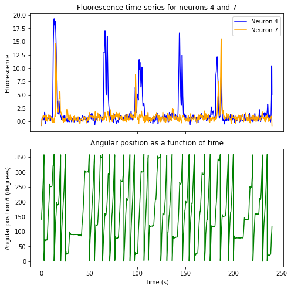

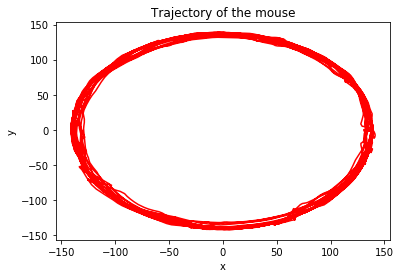

```python
fig, (ax1, ax2) = plt.subplots(2, 1, sharex=True)
plt.subplots_adjust(left=0, right=1, top=1.5, bottom=0, hspace=.15)

# First plot: fluorescence of neurons 4 and 7 as a function of time:

ax1.plot(t_im, dFonF_4, color='blue', label='Neuron 4')
ax1.plot(t_im, dFonF_7, color='orange', label='Neuron 7')
ax1.set_ylabel('Fluorescence')
plt.xlabel('Time (s)')
ax1.legend()
ax1.set_title('Fluorescence time series for neurons 4 and 7')

# Second plot: angular position of the mouse as a function of time:

ax2.plot(t_im, mouse_theta, color='green')
ax2.set_ylabel(r'Angular position $\theta$ (degrees)')
ax2.set_title('Angular position as a function of time')
plt.show()

# Third plot: x-y coordinates of the trajectory of the mouse:

plt.plot(mouse_x, mouse_y, color='red')
plt.xlabel('x')
plt.ylabel('y')
plt.title('Trajectory of the mouse')
```

## Section 2

In section 2 the autocorrelation for both neurons is computed. Two plots are displayed. The first one shows the autocorrelation for both cells in a full timescale while the second one corresponds to a time lag from -20 to +20 seconds.

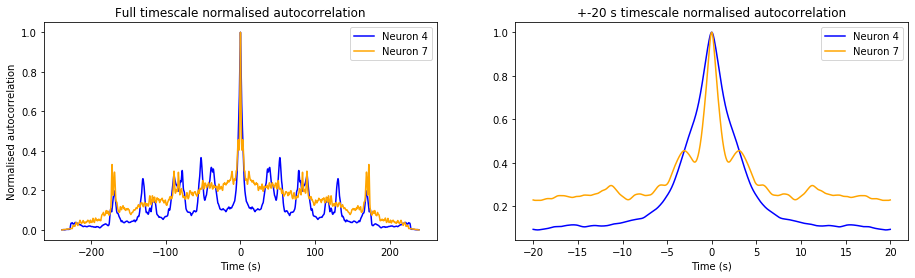

```python
w_1 = 239
w_2 = 20

# Calculation of the autocorrelation of neuron 4 and timescale modifications:

ac_4 = correlate(dFonF_4, dFonF_4)
maxcorr_4 = np.amax(ac_4) # for normalisation
ac_4 = ac_4/maxcorr_4
ctr_4 = int(np.floor(np.size(ac_4)/2))
idx_ac_4_1 = range(ctr_4-int(w_1*fs)-1, ctr_4+int(w_1*fs)+1)
idx_ac_4_2 = range(ctr_4-int(w_2*fs), ctr_4+int(w_2*fs)+1)
ac_4_1 = ac_4[idx_ac_4_1] # full timescale autocorrelation
ac_4_2 = ac_4[idx_ac_4_2] # +-20 seconds timescale autocorrelation
t_ac_4_1 = np.arange(0-w_1, 0+w_1, 1/fs)
t_ac_4_2 = np.arange(0-w_2, 0+w_2, 1/fs)

# Calculation of the autocorrelation of neuron 4 and timescale modifications:

ac_7 = correlate(dFonF_7, dFonF_7)
maxcorr_7 = np.amax(ac_7) # for normalisation
ac_7 = ac_7/maxcorr_7
ctr_7 = int(np.floor(np.size(ac_7)/2))
idx_ac_7_1 = range(ctr_7-int(w_1*fs)-1, ctr_7+int(w_1*fs)+1)
idx_ac_7_2 = range(ctr_7-int(w_2*fs), ctr_7+int(w_2*fs)+1)
ac_7_1 = ac_7[idx_ac_7_1] # full timescale autocorrelation
ac_7_2 = ac_7[idx_ac_7_2] # +-20 seconds timescale autocorrelation
t_ac_7_1 = np.arange(0-w_1, 0+w_1, 1/fs)
t_ac_7_2 = np.arange(0-w_2, 0+w_2, 1/fs)

fig, (ax3, ax4) = plt.subplots(1, 2)
plt.subplots_adjust(left=0, right=2, wspace=.2)

# First plot: full timescale normalised autocorrelation for cells 4 and 7:

ax3.plot(t_ac_4_1, ac_4_1, color='blue', label='Neuron 4')
ax3.plot(t_ac_7_1, ac_7_1, color='orange', label='Neuron 7')
ax3.set_ylabel('Normalised autocorrelation')
ax3.set_xlabel('Time (s)')
ax3.legend()
ax3.set_title('Full timescale normalised autocorrelation')

# Second plot: +-20 s timescale normalised autocorrelation for cells 4 and 7:

ax4.plot(t_ac_4_2, ac_4_2, color='blue', label='Neuron 4')
ax4.plot(t_ac_7_2, ac_7_2, color='orange', label='Neuron 7')
ax4.set_xlabel('Time (s)')
ax4.legend()
ax4.set_title('+-20 s timescale normalised autocorrelation')
```

## Section 3

In this section, the delay embedding for both cells (with m = 2) is produced. For the selection of the delay "tau", a common approach is to pick the time in which the autocorrelation crosses zero. However, this does not happen in the plots shown above. Because of this, to choose "tau" I have selected the time (for each cell) in which the autocorrelation decreases 30% (in the figures, from 1 to 0.7). With these criteria, tau for neuron 4 (tau_4) is around 1.36 seconds (42/fs), while tau for neuron 7 (tau_7) is approximately 0.71 seconds (22/fs). This is a reasonable approach, as it is visible in the results of the embedding shown below.

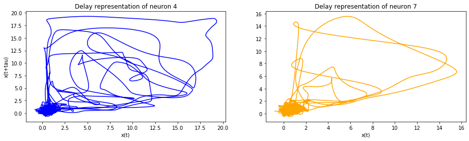

```python
fig, (ax5, ax6) = plt.subplots(1, 2)
plt.subplots_adjust(left=0, right=2, wspace=.2)

# Embedding of neuron 4:

tau_4 = 42/fs

idx_dFonF_4_aux = range(0, 7000)
idx_dFonF_4_tau = range(0+int(tau_4*fs), 7000+int(tau_4*fs))
dFonF_4_aux = dFonF_4[idx_dFonF_4_aux]
dFonF_4_tau = dFonF_4[idx_dFonF_4_tau]

# Plot of delay representation of neuron 4:

ax5.plot(dFonF_4_aux, dFonF_4_tau, color='blue')
ax5.set_ylabel('x(t+tau)')
ax5.set_xlabel('x(t)')
ax5.set_title('Delay representation of neuron 4')

# Embedding of neuron 7:

tau_7 = 22/fs

idx_dFonF_7_aux = range(0, 7000)
idx_dFonF_7_tau = range(0+int(tau_7*fs), 7000+int(tau_7*fs))
dFonF_7_aux = dFonF_7[idx_dFonF_7_aux]
dFonF_7_tau = dFonF_7[idx_dFonF_7_tau]

# Plot of delay representation of neuron 7:

ax6.plot(dFonF_7_aux, dFonF_7_tau, color='orange')
ax6.set_xlabel('x(t)')
ax6.set_title('Delay representation of neuron 7')
```

As it is observable in the figures, these embeddings provide valuable information about the strength and amount of spikes of each neuron during the recording time. Regarding neuron 7, it is clear that five spikes took place, two of them being noticeably stronger than the rest. On the other hand, the delay representation of neuron 4 is more unclear, although it is possible to say that cell 4 had more activity than cell 7. I tried other delays for the embedding of neuron 4 but the one represented (tau_4 = 1.36 s) gave the best results.

## Section 4

In section 4 a recurrence plot of the activity of cell 4 is displayed. So that action potentials are represented clearly, I chose a value of 0.5 for epsilon, which filters the noise.

```
5.859214273851967
```

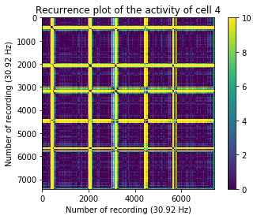

```python
# Recurrence plot of the activity of cell 4:

def rec_plot(s, eps=0.5, steps=10):

    d = pdist(s[:])
    print(d[7418])
    d = np.floor(d/eps)
    d[d>steps] = steps
    Z = squareform(d)

    return Z

rp = rec_plot(dFonF_4)

plt.imshow(rp)
plt.xlabel('Number of recording (30.92 Hz)')
plt.ylabel('Number of recording (30.92 Hz)')
plt.title('Recurrence plot of the activity of cell 4')
cbar = plt.colorbar()
```

As it is observable in the figure, the yellow parts of the recurrence plot represent the action potentials of neuron 4.

## Section 5

In section 5 the fluorescence data of the 75 recorded neurons is uploaded. In subsection 5.1 the activity of the population of neurons over time is plotted together with the average fluorescence of each cell. Later, in subsection 5.2, I proceed to do a 3-dimensional embedding of the neural population activity using multidimensional scaling (MDS).

```python
# Load data:

mat_contents = sio.loadmat('cw1_data2.mat')
dFonF = mat_contents['dFonF']
```

### 5.1

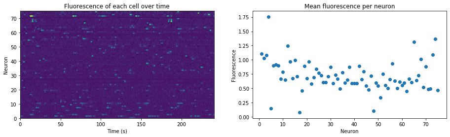

```python
fig, (ax7, ax8) = plt.subplots(1, 2)
plt.subplots_adjust(left=0, right=2, wspace=.2)

# Plot of fluorescence of each cell over time:

ax7.imshow(dFonF, extent=[0,7420/fs,0,75], aspect='auto')
ax7.set_ylabel('Neuron')
ax7.set_xlabel('Time (s)')
ax7.set_title('Fluorescence of each cell over time')

# Calculation of mean fluorescence for each neuron:

dFonF_mean = []
n = []

for i in range(75):
    dFonF_mean.append(np.mean(dFonF[i]))
    n.append(i+1)

# Plot of mean fluorescence per neuron:

ax8.scatter(n, dFonF_mean)
ax8.set_ylabel('Fluorescence')
ax8.set_xlabel('Neuron')
ax8.set_title('Mean fluorescence per neuron')
```

Notice how cell 4, analysed above, is a clear outlier in terms of fluorescence, with a mean of around 1.75. Most of the neurons have a mean between 0.5 and 1. However, the means of fluorescence do not follow a normal distribution, as shown in the probability plot below.

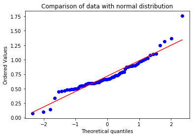

```python
res = stats.probplot(dFonF_mean, plot=plt)
plt.title('Comparison of data with normal distribution')
```

### 5.2

The chosen dissimilarity metric for the MDS was "cosine dissimilarity". This is because this metric measures the dissimilarity between different vectors (i.e. fluorescence of each neuron over time). This way, by reducing the data into three dimensions, it is possible to detect different patterns of neural activity correlated with the spatial coordinates of the mouse.

```python
# 3-D embedding using MDS (cosine dissimilarity):

X = 1 - cosine_similarity(np.transpose(dFonF))
embedding = MDS(n_components=3,dissimilarity='precomputed')
X_tr = embedding.fit_transform(X)
```

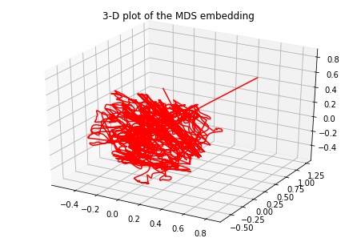

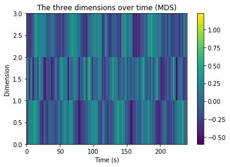

```python
# 3-D plot of the MDS embedding:

fig, ax9 = plt.subplots(1, 1)
ax9 = Axes3D(fig)
ax9.plot(X_tr[:,0], X_tr[:,1], X_tr[:,2], color='red')
ax9.set_title('3-D plot of the MDS embedding')

# The three dimensions over time plot:

fig, ax10 = plt.subplots(1, 1)
im = ax10.imshow(X_tr.T, extent=[0,7420/fs,0,3], aspect='auto')
ax10.set_ylabel('Dimension')
ax10.set_xlabel('Time (s)')
ax10.set_title('The three dimensions over time (MDS)')
plt.colorbar(im)
```

Ideally, it should be possible to observe circular pathways in the 3-D plot. In fact, in the "the three dimensions over time (MDS)" plot there is a visible pattern. However, the noise disturbs the representation. Because of this, I proceed by filtering the data.

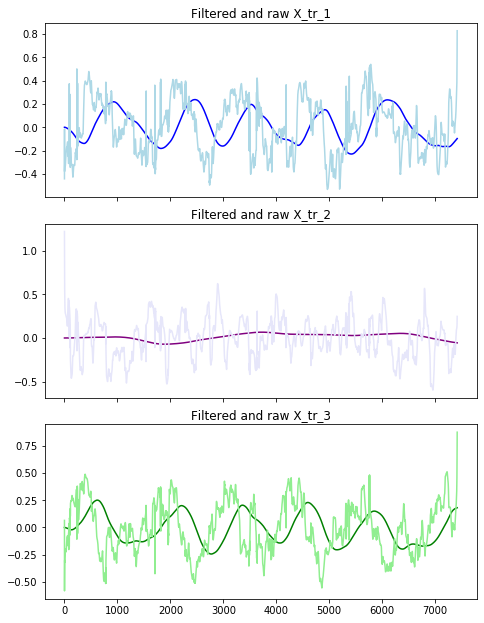

```python
# Data smoothing with Butterworth filters:

t_1 = []
t_2 = []
t_3 = []

for i in range(7420):
    t_1.append(X_tr[i][0])
    t_2.append(X_tr[i][1])
    t_3.append(X_tr[i][2])

fig, (ax11, ax12, ax13) = plt.subplots(3, 1, sharex=True)
plt.subplots_adjust(left=0, right=1, top=2, bottom=0, hspace=.15)

sos_1 = butter(2, 0.025, btype='lowpass', fs=30.92, output='sos')
sos_2 = butter(3, 0.01, btype='lowpass', fs=30.92, output='sos')
sos_3 = butter(2, 0.025, btype='lowpass', fs=30.92, output='sos')
filt_1 = sosfilt(sos_1, t_1)
filt_2 = sosfilt(sos_2, t_2)
filt_3 = sosfilt(sos_3, t_3)

# Filtered and raw data representation:

ax11.plot(filt_1, color='blue')
ax11.plot(t_1, color='lightblue')
ax11.set_title('Filtered and raw X_tr_1')
ax12.plot(filt_2, color='purple')
ax12.plot(t_2, color='lavender')
ax12.set_title('Filtered and raw X_tr_2')
ax13.plot(filt_3, color='green')
ax13.plot(t_3, color='lightgreen')
ax13.set_title('Filtered and raw X_tr_3')
```

In the plots above the filtered and raw data are represented together. X_tr_1 and X_tr_3 are similar to sinusoidal signals, while X_tr_2 is more or less flat. After the data smoothing with Butterworth filters, I again plot the desired figures.

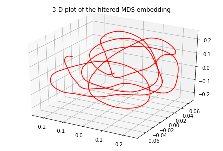

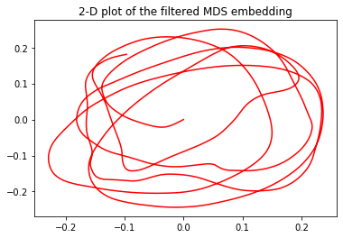

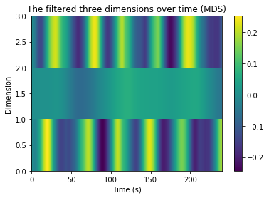

```python
X_tr_filt = [filt_1,filt_2,filt_3]

# 3-D plot of the filtered MDS embedding:

fig, ax14 = plt.subplots(1, 1)
ax14 = Axes3D(fig)
ax14.plot(filt_1, filt_2, filt_3, color='red')
ax14.set_title('3-D plot of the filtered MDS embedding')

# 2-D plot of the filtered MDS embedding:

fig, ax15 = plt.subplots(1, 1)
ax15.plot(filt_1, filt_3, color='red')
ax15.set_title('2-D plot of the filtered MDS embedding')

# The filtered three dimensions over time plot:

fig, ax16 = plt.subplots(1, 1)
im = ax16.imshow(X_tr_filt, extent=[0,7420/fs,0,3], aspect='auto')
ax16.set_ylabel('Dimension')
ax16.set_xlabel('Time (s)')
ax16.set_title('The filtered three dimensions over time (MDS)')
plt.colorbar(im)
```

Now the pattern is much more visible. In the 3-D plot, it is possible to observe the circular path followed by the mouse. Even though the representation is far from perfect, this is normal because we are analysing a reduced amount of data (75 neurons).

## Section 6

In section 6 a recurrence plot of the 3-dimensional activity calculated in section 5 is displayed.

```
1.7926252889433698
```

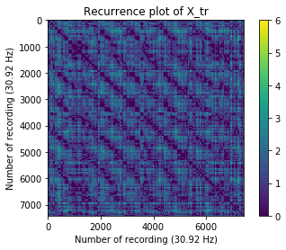

```python
# Recurrence plot of X_tr:

def rec_plot(s, eps=0.3, steps=10):

    d = pdist(s[:])
    print(d[7418])
    d = np.floor(d/eps)
    d[d>steps] = steps
    Z = squareform(d)

    return Z

rp = rec_plot(X_tr)

plt.imshow(rp)
plt.xlabel('Number of recording (30.92 Hz)')
plt.ylabel('Number of recording (30.92 Hz)')
plt.title('Recurrence plot of X_tr')
cbar = plt.colorbar()
```

In this case, with the raw data, it is possible to observe a sequence in the recurrence plot. Note that this sequence is repeated 5 times, which is the number of circular laps in the filtered 3-D plot of the previous section.

```
0.21284116205293935
```

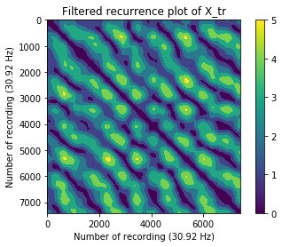

```python
X_tr_filt_T = []

for i in range(7420):
    X_tr_filt_T.append([filt_1[i],filt_2[i],filt_3[i]])

X_tr_filt_T = np.array(X_tr_filt_T)

# Recurrence plot of filtered X_tr:

def rec_plot(s, eps=0.1, steps=10):

    d = pdist(s[:])
    print(d[7418])
    d = np.floor(d/eps)
    d[d>steps] = steps
    Z = squareform(d)

    return Z

rp = rec_plot(X_tr_filt_T)

plt.imshow(rp)
plt.xlabel('Number of recording (30.92 Hz)')
plt.ylabel('Number of recording (30.92 Hz)')
plt.title('Filtered recurrence plot of X_tr')
cbar = plt.colorbar()
```

In the filtered recurrence plot the laps are more clear.